# An introduction to Difference-in-difference and Synthetic control methods for Epidemiologists

Society for Epidemiologic Research (SER) Workshop: Part 2/3

Roch Nianogo (niaroch@ucla.edu) & Tarik Benmarhnia (tbenmarhnia@health.ucsd.edu)

11 July, 2022

# 1 Loading the data

```r
#First load the data
mydata <- read_csv(here("data", "sim_data.csv"))
year_policy <- 2000

mydata <- mydata %>%
  mutate(year_rec = year - year_policy,
         post     = ifelse(year>=year_policy,1,0),
         treated  = ifelse(state %in% c("Alabama",  "Alaska",
                                        "Arizona", "Arkansas", "California"), 1,0),
         treatedpost = treated*post)
```

# 2 Pre-post designs

Pre-post analysis (before-after) no control group: One state, two time points  
- Subset the data to California and the years 1995 and 2005  
- Preview the data  
- Plot the data  
- Fit a linear model to estimate the effect of the policy on the outcome y  
- What are potential problems

```r
##Create the data
dt <- mydata %>%
  filter(state=="California",
         year %in% c(1995, 2005))


##Preview the data
head(dt)
```

| state | state_num | year | xit | xt | xi | y | year_rec | post | treated | treatedpost |
| --- | --- | --- | --- | --- | --- | --- | --- | --- | --- | --- |
| California | 5 | 1995 | 2.363548 | 19.32158 | 6.774229 | 87.92101 | -5 | 0 | 1 | 0 |
| California | 5 | 2005 | 2.866742 | 24.70796 | 6.774229 | 211.22672 | 5 | 1 | 1 | 1 |

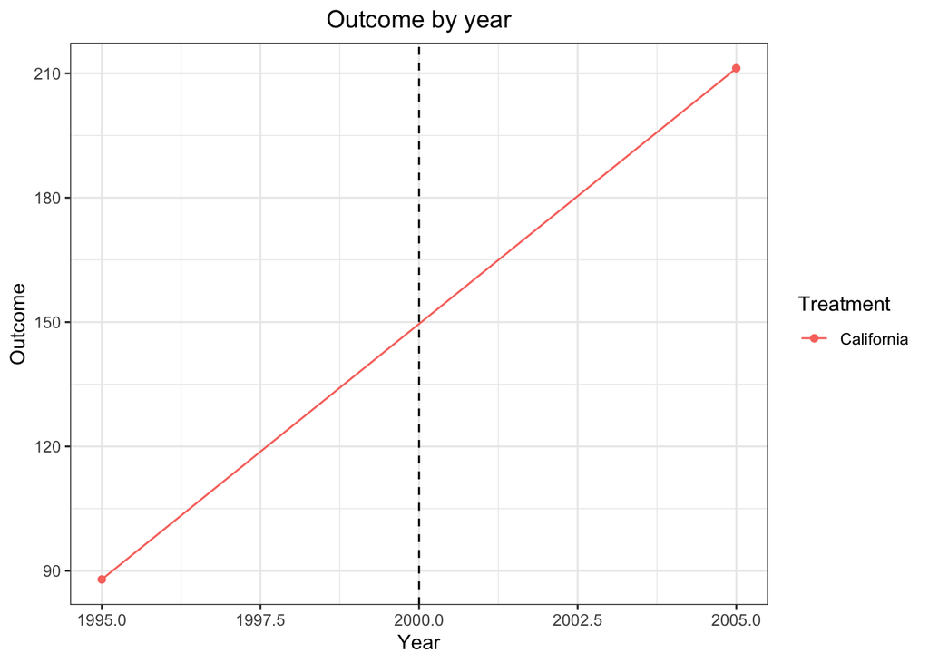

```r
##Plot the data
dt %>%
  ggplot(aes(x=year, y=y, group=state, color = state)) +
  labs(title = paste("Outcome by year"),
       x = "Year",
       y = "Outcome",
       colour = "Treatment") +
  geom_line() +
  geom_point() +
  geom_vline(xintercept = year_policy, lty=2) +
  theme_bw() +
  theme(plot.title = element_text(hjust = 0.5))
```

The following model is used to estimate the effect of the policy on the outcome y
$$\operatorname{y} = \alpha + \beta_{1}(\operatorname{post}) + \beta_{2}(\operatorname{xi}) + \beta_{3}(\operatorname{xt}) + \beta_{4}(\operatorname{xit}) + \epsilon$$

| term | estimate | std.error | statistic | p.value |
| --- | --- | --- | --- | --- |
| (Intercept) | 87.92101 | NaN | NaN | NaN |
| post | 123.30571 | NaN | NaN | NaN |
| xi | NA | NA | NA | NA |
| xt | NA | NA | NA | NA |
| xit | NA | NA | NA | NA |

**Potential problems**  
- The years before and after the policy have been implemented are picked arbitrarily  
- It is impossible to get standard errors  
- It is impossible to adjust for covariates  
- This model would be wrong if the parallel trend assumption is violated  
- This model would be wrong if the common shock assumption is violated

**Conclusion** - As expected the estimate is biased and standard errors inestimable

# 3 Controlled pre-post designs

Pre-post analysis (before-after) with a control group: Two states, two time points

- Subset the data to California and Georgia and the years 1995 and 2005
- Preview the data
- Plot the data
- Fit a linear model to estimate the effect of the policy on the outcome y
- What are potential problems

```r
##Create the data
dt1 <- mydata %>%
  filter(state=="California" | state=="Georgia",
         year %in% c(1995, 2005))

##Preview the data
head(dt1)
```

| state | state_num | year | xit | xt | xi | y | year_rec | post | treated | treatedpost |
| --- | --- | --- | --- | --- | --- | --- | --- | --- | --- | --- |
| California | 5 | 1995 | 2.363548 | 19.32158 | 6.774229 | 87.92101 | -5 | 0 | 1 | 0 |
| California | 5 | 2005 | 2.866742 | 24.70796 | 6.774229 | 211.22672 | 5 | 1 | 1 | 1 |
| Georgia | 10 | 1995 | 64.289321 | 19.32158 | 2.215942 | 265.26978 | -5 | 0 | 0 | 0 |
| Georgia | 10 | 2005 | 77.976380 | 24.70796 | 2.215942 | 327.08836 | 5 | 1 | 0 | 0 |

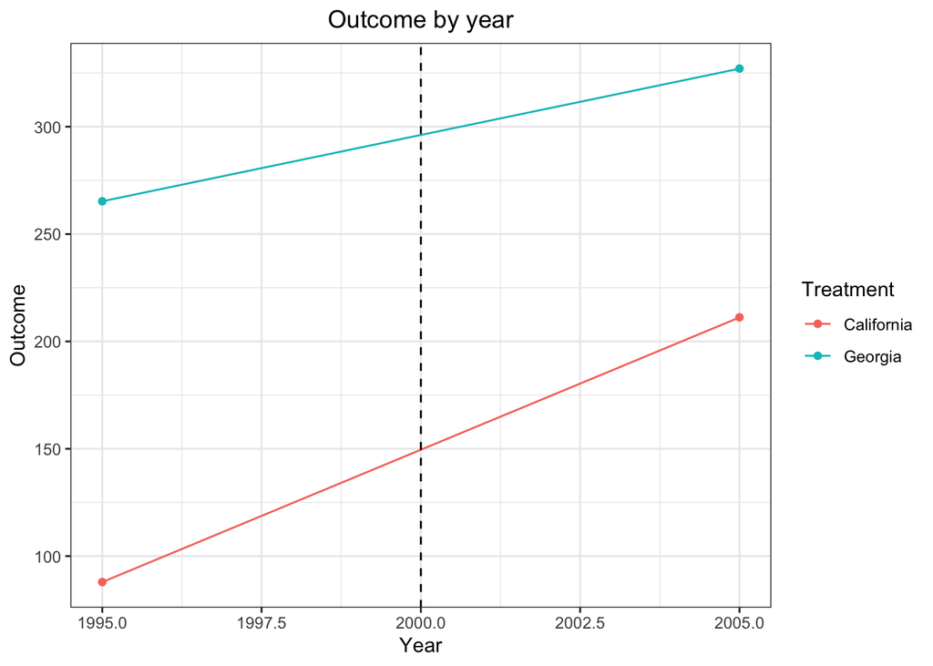

```r
##Plot the data
dt1 %>%
  ggplot(aes(x=year, y=y, group=state, color = state)) +
  labs(title = paste("Outcome by year"),
       x = "Year",
       y = "Outcome",
       colour = "Treatment") +
  geom_line() +
  geom_point() +
  geom_vline(xintercept = year_policy, lty=2) +
  theme_bw() +
  theme(plot.title = element_text(hjust = 0.5))
```

The following model is used to estimate the effect of the policy on the outcome y
$$\operatorname{y} = \alpha + \beta_{1}(\operatorname{treated}) + \beta_{2}(\operatorname{post}) + \beta_{3}(\operatorname{treated} \times \operatorname{post}) + \epsilon$$

[output not shown]

**Potential problems**

- The years before and after the policy have been implemented are picked arbitrarily
- The control units are picked arbitrarily
- It is impossible to get standard errors
- It is impossible to adjust for covariates
- This model would be wrong if the parallel trend assumption is violated
- This model would be wrong if the common shock assumption is violated

**Conclusion** - As expected the estimate is biased and standard errors inestimable

# 4 Interrupted Time Series Design

Interupted time series: One state, Multiple time points

- Subset the data to California
- Preview the data
- Plot the data
- Fit a linear model to estimate the effect of the policy on the outcome y
- What are potential problems

```r
##Create the data
dt2 <- mydata %>%
  filter(state=="California")

##Preview the data
head(dt2)
```

| state | state_num | year | xit | xt | xi | y | year_rec | post | treated | treatedpost |
| --- | --- | --- | --- | --- | --- | --- | --- | --- | --- | --- |
| California | 5 | 1961 | -0.1650719 | 0.9395244 | 6.774229 | 14.72379 | -39 | 0 | 1 | 0 |
| California | 5 | 1962 | -0.1129935 | 1.7698225 | 6.774229 | 17.07625 | -38 | 0 | 1 | 0 |
| California | 5 | 1963 | -0.1084601 | 4.0587083 | 6.774229 | 20.36918 | -37 | 0 | 1 | 0 |
| California | 5 | 1964 | -0.0808995 | 3.0705084 | 6.774229 | 19.38007 | -36 | 0 | 1 | 0 |
| California | 5 | 1965 | 0.1803213 | 3.6292877 | 6.774229 | 23.92489 | -35 | 0 | 1 | 0 |
| California | 5 | 1966 | 0.4905550 | 5.7150650 | 6.774229 | 28.34684 | -34 | 0 | 1 | 0 |

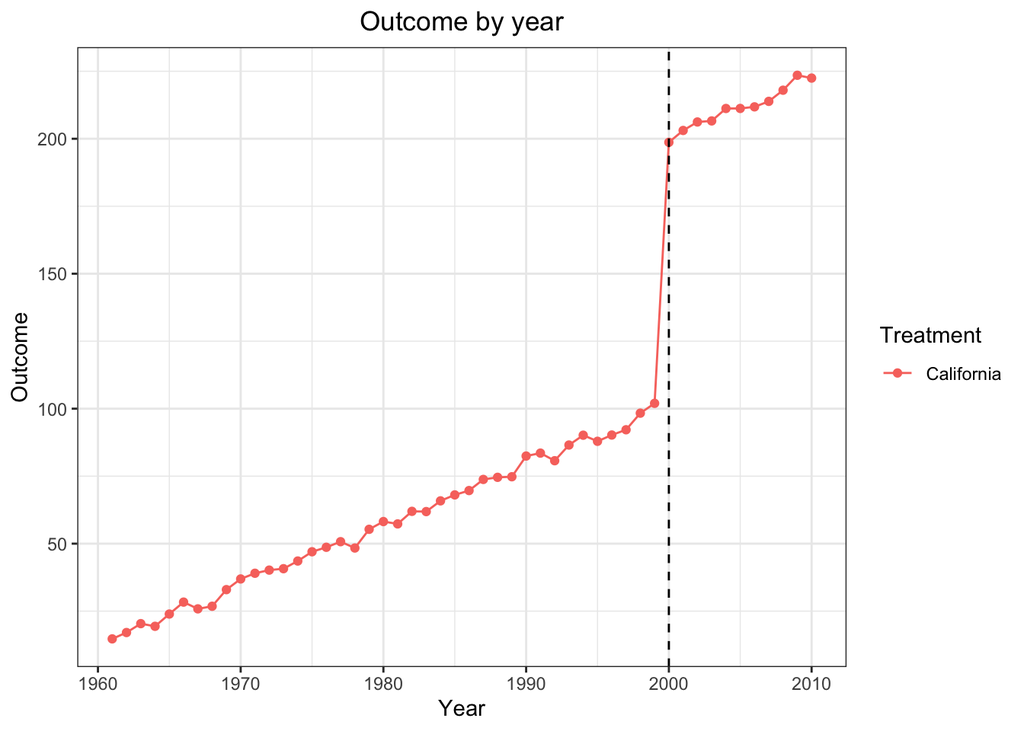

```r
##Plot the data
dt2 %>%
  ggplot(aes(x=year, y=y, group=state, color = state)) +
  labs(title = paste("Outcome by year"),
       x = "Year",
       y = "Outcome",
       colour = "Treatment") +
  geom_line() +
  geom_point() +
  geom_vline(xintercept = year_policy, lty=2) +
  theme_bw() +
  theme(plot.title = element_text(hjust = 0.5))
```

The following model is used to estimate the effect of the policy on the outcome y
$$\operatorname{y} = \alpha + \beta_{1}(\operatorname{year\_rec}) + \beta_{2}(\operatorname{post}) + \beta_{3}(\operatorname{xi}) + \beta_{4}(\operatorname{xt}) + \beta_{5}(\operatorname{xit}) + \beta_{6}(\operatorname{year\_rec} \times \operatorname{post}) + \epsilon$$

| term | estimate | std.error | statistic | p.value |
| --- | --- | --- | --- | --- |
| (Intercept) | 73.9385915 | 4.7749028 | 15.484837 | 2.008945e-19 |
| year_rec | 1.5576919 | 0.1155636 | 13.479086 | 3.172831e-17 |
| post | 98.6112210 | 0.8991056 | 109.677023 | 2.719506e-55 |
| xi | NA | NA | NA | NA |
| xt | 0.9687891 | 0.2115235 | 4.580055 | 3.806377e-05 |
| xit | 2.6728728 | 0.6067036 | 4.405566 | 6.670066e-05 |
| year_rec:post | 0.1523435 | 0.1354244 | 1.124934 | 2.667164e-01 |

**Potential problem (s)**

- This model would be wrong if the common assumption is violated(that is if an event occurs in the treated unit at or after the time of the policy that is not attributable to the policy)

**Conclusion** - As expected the estimate is slightly biased

# 5 Controlled Interrupted Time Series (CITS) or Difference-in-Difference Designs

## 5.1 Step 1: Checking the parallel trends assumption

Check the parallel trends assumptions  
To do so:  
- Restrict the data to the period before the policy  
- Run a linear regression of the outcome on time-varying covariates and on an interaction term between treated indicator and year

```r
p_load("estimatr") #for the lm_robust() function
pretrend_data <- mydata %>%
  filter(post == 0)

res_pretrend <-  lm(y ~ treated*year + xit + xt + xi,
                    data = pretrend_data)
tidy(res_pretrend) %>% flextable()
```

| term | estimate | std.error | statistic | p.value |
| --- | --- | --- | --- | --- |
| (Intercept) | -2.911488e+03 | 75.262307780 | -38.68454970 | 3.054114e-243 |
| treated | -3.851410e+00 | 39.776305174 | -0.09682675 | 9.228740e-01 |
| year | 1.486308e+00 | 0.038428259 | 38.67746527 | 3.565872e-243 |
| xit | 3.020824e+00 | 0.004566011 | 661.58919014 | 0.000000e+00 |
| xt | 1.048660e+00 | 0.075719984 | 13.84918944 | 1.146756e-41 |
| xi | 4.906902e-01 | 0.075752395 | 6.47755338 | 1.177860e-10 |
| treated:year | 5.941112e-03 | 0.020088331 | 0.29574940 | 7.674531e-01 |

```r
#the lm_robust procedure is best because SE are correctly estimated
res_pretrend <- lm_robust(y ~ treated*year + xit, data = pretrend_data,
                          fixed_effects=state,
                          clusters = state, se_type = "stata")
tidy(res_pretrend) %>% flextable()
```

```
## 1 coefficient  not defined because the design matrix is rank deficient
```

| term | estimate | std.error | statistic | p.value | conf.low | conf.high | df | outcome |
| --- | --- | --- | --- | --- | --- | --- | --- | --- |
| treated | NA | NA | NA | NA | NA | NA | NA | y |
| year | 2.014225472 | 0.002594649 | 776.299757 | 7.114414e-102 | 2.009011330 | 2.0194396 | 49 | y |
| xit | 3.003860244 | 0.002893339 | 1038.198336 | 4.636818e-108 | 2.998045860 | 3.0096746 | 49 | y |
| treated:year | 0.008744565 | 0.005394691 | 1.620958 | 1.114450e-01 | -0.002096472 | 0.0195856 | 49 | y |

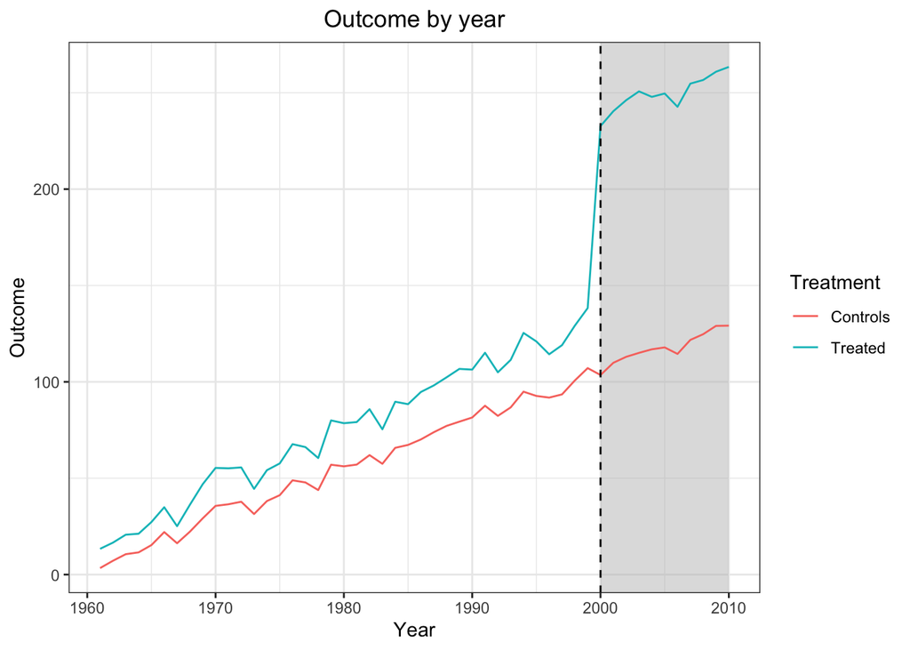

```r
#Visual trends
mydata %>%
  group_by(year, treated) %>%
  summarise(y=mean(y),.groups="keep") %>%
  ggplot(aes(x=year, y=y, group=treated, color = factor(treated))) +
  annotate("rect", fill = "gray", alpha = 0.5,
           xmin = 2000, xmax = 2010,
           ymin = -Inf, ymax = Inf) +
  labs(title = paste("Outcome by year"),
       x = "Year",
       y = "Outcome",
       colour = "Treatment") +
  geom_line() +
  scale_color_discrete(labels=c("Controls", "Treated")) +
  geom_vline(xintercept = year_policy, lty=2) +
  theme_bw() +
  theme(plot.title = element_text(hjust = 0.5))
```

## 5.2 Step 2: Implementing the DID analysis method

- Fit a linear model with the treated, post and their interaction
- Don’t forget to add any other time-varying covariates
- What is the regression coefficient of the interaction term

```r
#Method 1: Lm_robust()
p_load("estimatr")
dta <- lm_robust(y ~ treated*post + factor(year) + xit,
                 data = mydata,
                 fixed_effects=state,
                 clusters = state,
                 se_type = "stata")
dta
```

```
## 2 coefficients  not defined because the design matrix is rank deficient
```

```
##                    Estimate  Std. Error     t value      Pr(>|t|)   CI Lower
## treated                  NA          NA          NA            NA         NA
## post              89.630857 0.206627198  433.780535  1.719813e-89  89.215624
## factor(year)1962   3.255804 0.194706345   16.721611  6.906548e-22   2.864527
## factor(year)1963   6.703224 0.210911604   31.782149  2.308333e-34   6.279381
## factor(year)1964   7.344910 0.191444019   38.365837  3.232437e-38   6.960189
## factor(year)1965   8.970397 0.202596295   44.277202  3.500079e-41   8.563265
## factor(year)1966  12.979390 0.242598981   53.501418  3.957929e-45  12.491869
## factor(year)1967  13.063027 0.214492122   60.902131  7.595035e-48  12.631989
## factor(year)1968  12.478596 0.227137620   54.938482  1.102758e-45  12.022146
## factor(year)1969  16.185107 0.214767565   75.361040  2.480943e-52  15.753515
## factor(year)1970  19.912781 0.172357866  115.531608  2.258734e-61  19.566415
## factor(year)1971  22.207010 0.254033646   87.417595  1.817238e-55  21.696511
## factor(year)1972  24.450828 0.211592380  115.556277  2.235311e-61  24.025617
## factor(year)1973  24.287340 0.199893982  121.501107  1.929441e-62  23.885638
## factor(year)1974  27.427632 0.185008145  148.250945  1.154312e-66  27.055845
## factor(year)1975  29.201221 0.183759580  158.909924  3.870868e-68  28.831942
## factor(year)1976  33.466107 0.211895039  157.937188  5.226645e-68  33.040288
## factor(year)1977  34.120386 0.214339110  159.188801  3.552761e-68  33.689655
## factor(year)1978  32.777502 0.214041018  153.136546  2.364792e-67  32.347371
## factor(year)1979  37.350236 0.230879689  161.773591  1.616009e-68  36.886266
## factor(year)1980  38.145973 0.230805711  165.273091  5.673209e-69  37.682152
## factor(year)1981  40.399456 0.220943029  182.850106  4.040990e-71  39.955455
## factor(year)1982  42.031323 0.251098865  167.389538  3.044503e-69  41.526721
## factor(year)1983  43.839074 0.230305309  190.351988  5.649624e-72  43.376258
## factor(year)1984  46.276782 0.249633686  185.378756  2.063616e-71  45.775124
## factor(year)1985  50.394075 0.223653961  225.321631  1.469014e-75  49.944626
## factor(year)1986  49.467131 0.222126508  222.698009  2.606325e-75  49.020751
## factor(year)1987  54.752069 0.205729231  266.136559  4.237345e-79  54.338641
## factor(year)1988  55.520055 0.211359880  262.680197  8.036849e-79  55.095311
## factor(year)1989  55.300988 0.209229476  264.307827  5.939157e-79  54.880526
## factor(year)1990  60.513442 0.217812824  277.823136  5.166044e-80  60.075731
## factor(year)1991  63.332609 0.223195126  283.754447  1.836085e-80  62.884082
## factor(year)1992  63.463948 0.202014870  314.154832  1.256635e-82  63.057983
## factor(year)1993  66.111643 0.172440620  383.387878  7.289084e-87  65.765111
## factor(year)1994  67.697322 0.222670377  304.024823  6.256891e-82  67.249849
## factor(year)1995  68.030113 0.207123321  328.452213  1.420875e-83  67.613883
## factor(year)1996  73.117487 0.246209456  296.972700  1.974814e-81  72.622711
## factor(year)1997  72.488070 0.221654526  327.031760  1.756894e-83  72.042638
## factor(year)1998  76.011948 0.204166773  372.303227  3.067610e-86  75.601660
```

[output cut: 53 more lines]

```
## factor(year)1998  76.4222369 49
## factor(year)1999  79.4399050 49
## factor(year)2000 -11.7598620 49
## factor(year)2001  -8.0439874 49
## factor(year)2002  -6.1882254 49
## factor(year)2003  -6.5726891 49
## factor(year)2004  -1.0692223 49
## factor(year)2005  -0.3069451 49
## factor(year)2006          NA NA
## factor(year)2007   2.1242701 49
## factor(year)2008   6.3118584 49
## factor(year)2009  11.3216471 49
## factor(year)2010   8.6941690 49
## xit                3.0029157 49
## treated:post     100.2215836 49
```

```r
did <- round(data.frame(ATT     = dta$coefficients["treated:post"],
                        se      = dta$std.error["treated:post"],
                        low_ci  = dta$conf.low["treated:post"],
                        high_ci = dta$conf.hig["treated:post"]),2)
did
```

|  | ATT | se | low_ci | high_ci |
| --- | --- | --- | --- | --- |
| treated:post | 99.98 | 0.12 | 99.74 | 100.22 |

```r
#Method 2: lmer(): Multilevel
fit1 <- lmerTest::lmer(y ~ treated + post + treated:post + xt + xi + xit + (1| state) + (1 | year),
                      data = mydata,
                      REML = T)
tidy(fit1) %>% flextable()
```

| effect | group | term | estimate | std.error | statistic | df | p.value |
| --- | --- | --- | --- | --- | --- | --- | --- |
| fixed |  | (Intercept) | -0.3406062 | 1.447133769 | -0.2353661 | 93.93876 | 8.144369e-01 |
| fixed |  | treated | 8.0901756 | 2.620423498 | 3.0873542 | 47.01042 | 3.382822e-03 |
| fixed |  | post | 0.7405684 | 1.426779607 | 0.5190489 | 47.01150 | 6.061617e-01 |
| fixed |  | xt | 3.9306067 | 0.081476750 | 48.2420652 | 47.00858 | 1.075109e-41 |
| fixed |  | xi | 0.4689964 | 0.441351409 | 1.0626371 | 46.99170 | 2.933771e-01 |
| fixed |  | xit | 2.9998137 | 0.002056406 | 1458.7651267 | 2426.33202 | 0.000000e+00 |
| fixed |  | treated:post | 99.9809626 | 0.159890592 | 625.3086030 | 2399.08475 | 0.000000e+00 |
| ran_pars | state | sd__(Intercept) | 2.7910760 | NA | NA | NA | NA |
| ran_pars | year | sd__(Intercept) | 2.9471046 | NA | NA | NA | NA |
| ran_pars | Residual | sd__Observation | 0.9922305 | NA | NA | NA | NA |

```r
#Other specifications
fit2 <-  lm(y ~  xit + xi + xt + factor(state) + factor(year) + treated:post, data = mydata)
tidy(fit2) %>% flextable()
```

| term | estimate | std.error | statistic | p.value |
| --- | --- | --- | --- | --- |
| (Intercept) | -6.198098e+00 | 0.219460079 | -2.824249e+01 | 9.533790e-152 |
| xit | 2.999644e+00 | 0.002063475 | 1.453686e+03 | 0.000000e+00 |
| xi | 2.714599e+00 | 0.033601066 | 8.078907e+01 | 0.000000e+00 |
| xt | 3.921321e+00 | 0.008010965 | 4.894942e+02 | 0.000000e+00 |
| factor(state)Alaska | 7.537253e-01 | 0.214927414 | 3.506883e+00 | 4.617169e-04 |
| factor(state)Arizona | -7.741204e-01 | 0.198566703 | -3.898541e+00 | 9.942865e-05 |
| factor(state)Arkansas | -7.351393e+00 | 0.221842909 | -3.313783e+01 | 1.346309e-198 |
| factor(state)California | -2.007721e+00 | 0.199230467 | -1.007738e+01 | 2.019667e-23 |
| factor(state)Colorado | -1.879468e+00 | 0.173512720 | -1.083187e+01 | 9.990794e-27 |
| factor(state)Connecticut | 6.255610e+00 | 0.209287751 | 2.988999e+01 | 3.825502e-167 |
| factor(state)Delaware | -4.239932e-01 | 0.178845225 | -2.370727e+00 | 1.783174e-02 |
| factor(state)Florida | 4.395374e+00 | 0.199086374 | 2.207773e+01 | 1.742513e-98 |
| factor(state)Georgia | 4.099885e-01 | 0.198964592 | 2.060610e+00 | 3.944781e-02 |
| factor(state)Hawaii | 4.302842e+00 | 0.180791795 | 2.379998e+01 | 1.399816e-112 |
| factor(state)Idaho | -7.247972e-01 | 0.192566489 | -3.763880e+00 | 1.713111e-04 |
| factor(state)Illinois | -1.339839e+00 | 0.188934107 | -7.091568e+00 | 1.737399e-12 |
| factor(state)Indiana | 1.324026e+01 | 0.203033206 | 6.521227e+01 | 0.000000e+00 |
| factor(state)Iowa | 2.272889e+00 | 0.202661858 | 1.121518e+01 | 1.733404e-28 |
| factor(state)Kansas | 2.046487e+00 | 0.181486766 | 1.127624e+01 | 8.983173e-29 |
| factor(state)Kentucky | 2.715580e+00 | 0.180123552 | 1.507621e+01 | 3.852203e-49 |
| factor(state)Louisiana | 2.682825e-01 | 0.186216360 | 1.440703e+00 | 1.497990e-01 |
| factor(state)Maine | 1.505718e+00 | 0.177277312 | 8.493575e+00 | 3.460630e-17 |
| factor(state)Maryland | -6.698522e-01 | 0.176043463 | -3.805039e+00 | 1.453275e-04 |
| factor(state)Massachusetts | 1.874576e+00 | 0.207545767 | 9.032111e+00 | 3.373501e-19 |
| factor(state)Michigan | 6.059575e+00 | 0.223413938 | 2.712264e+01 | 1.569146e-141 |
| factor(state)Minnesota | 8.361282e-02 | 0.177345238 | 4.714692e-01 | 6.373486e-01 |
| factor(state)Mississippi | 9.157084e+00 | 0.196617816 | 4.657301e+01 | 0.000000e+00 |
| factor(state)Missouri | 8.682049e-01 | 0.194806956 | 4.456745e+00 | 8.703806e-06 |
| factor(state)Montana | -3.388306e+00 | 0.177833712 | -1.905323e+01 | 1.757949e-75 |
| factor(state)Nebraska | 2.279158e+00 | 0.189899766 | 1.200190e+01 | 2.859723e-32 |

[output cut: 73 more lines]

```r
p_load("lme4", "lmerTest")
fit3 <-  lmerTest::lmer(y ~ treated:post + xit + xi + xt + (1| state) + (1 | year),
                        data = mydata, REML = T)
tidy(fit3) %>% flextable()
```

| effect | group | term | estimate | std.error | statistic | df | p.value |
| --- | --- | --- | --- | --- | --- | --- | --- |
| fixed |  | (Intercept) | -2.8981037 | 1.175000493 | -2.466470 | 93.99986 | 1.545702e-02 |
| fixed |  | xit | 2.9998241 | 0.002057434 | 1458.041763 | 2423.15608 | 0.000000e+00 |
| fixed |  | xi | 1.6467494 | 0.240871782 | 6.836622 | 48.03023 | 1.305345e-08 |
| fixed |  | xt | 3.9605267 | 0.057090135 | 69.373224 | 48.02936 | 8.072555e-50 |
| fixed |  | treated:post | 99.9874751 | 0.159869112 | 625.433354 | 2400.37026 | 0.000000e+00 |
| ran_pars | state | sd__(Intercept) | 3.0295047 | NA | NA | NA | NA |
| ran_pars | year | sd__(Intercept) | 2.9245224 | NA | NA | NA | NA |
| ran_pars | Residual | sd__Observation | 0.9922313 | NA | NA | NA | NA |